# Homework 01

Author

Lu Gong

## Question 1: Least squares and matrix calculations

### 1a. Generate the data, inspect the design matrix, and estimate the coefficients

**Show R code**

```r
set.seed(43201)

n <- 100
p <- 5

predictors <- matrix(
  rnorm(n * p),
  nrow = n,
  ncol = p
)
colnames(predictors) <- paste0("x", seq_len(p))

X <- cbind(intercept = 1, predictors)

beta_true <- c(
  intercept = 3,
  x1 = 1.4,
  x2 = -0.9,
  x3 = 0.7,
  x4 = 0,
  x5 = 1.1
)

epsilon <- rnorm(n, mean = 0, sd = 0.7)
y <- drop(X %*% beta_true + epsilon)

X_dimensions <- dim(X)
X_rank <- qr(X)$rank

# I use QR here so I do not have to invert t(X) %*% X.
beta_hat <- qr.solve(X, y)

coefficient_comparison <- data.frame(
  term = colnames(X),
  generating_coefficient = unname(beta_true),
  estimated_coefficient = unname(beta_hat),
  estimation_difference = unname(beta_hat - beta_true),
  row.names = NULL
)

data.frame(
  quantity = c("number of rows", "number of columns", "rank"),
  value = c(X_dimensions[1], X_dimensions[2], X_rank)
)
```

```
           quantity value
1    number of rows   100
2 number of columns     6
3              rank     6
```

**Show R code**

```r
print(coefficient_comparison, digits = 6)
```

```
       term generating_coefficient estimated_coefficient estimation_difference
1 intercept                    3.0             3.0063210            0.00632099
2        x1                    1.4             1.4171604            0.01716042
3        x2                   -0.9            -0.8883453            0.01165468
4        x3                    0.7             0.7952834            0.09528339
5        x4                    0.0             0.0484378            0.04843780
6        x5                    1.1             1.1319341            0.03193413
```

I got a $100\times6$ design matrix because there are five predictors plus the intercept. Its rank is 6, so none of its columns is redundant in this sample. The estimated coefficients are fairly close to the values used to generate the data. For example, the intercept estimate is 3.0063 instead of 3, while the $x_3$ estimate is 0.7953 instead of 0.7. I would not expect an exact match because the response includes random error and this is only one sample.

### 1b. Fitted values, residuals, and training RMSE

**Show R code**

```r
fitted_values <- drop(X %*% beta_hat)
residuals <- y - fitted_values
training_rmse <- sqrt(mean(residuals^2))

data.frame(
  metric = "training RMSE",
  value = training_rmse
)
```

```
         metric     value
1 training RMSE 0.6763696
```

The training RMSE is 0.6764. I interpret this as the typical size of an in-sample prediction error, measured in the same units as $y$. Since the error standard deviation used in the simulation was 0.7, this result seems reasonable.

### 1c. Orthogonality of the residuals

**Show R code**

```r
Xt_residuals <- drop(crossprod(X, residuals))
orthogonality_infinity_norm <- max(abs(Xt_residuals))

data.frame(
  metric = "infinity norm of t(X) %*% residuals",
  value = orthogonality_infinity_norm
)
```

```
                               metric        value
1 infinity norm of t(X) %*% residuals 5.878631e-14
```

I got approximately $5.88\times10^{-14}$ for the infinity norm, which is basically zero for this calculation. This makes sense because the least-squares normal equations give $X^{\mathsf T}r=0$. In other words, the residuals are orthogonal to every column of $X$. The small nonzero remainder is from numerical rounding rather than a meaningful violation of this property.

## Question 2: Gaussian likelihood for linear regression

### 2a. Why Gaussian maximum likelihood gives the least-squares estimate

When $\sigma^2$ is fixed, the first part of the log-likelihood does not change with $\boldsymbol\beta$. The remaining part is the negative RSS divided by $2\sigma^2$. Therefore, making the log-likelihood as large as possible means making RSS as small as possible. This is the same problem solved by least squares, so the MLE of $\boldsymbol\beta$ is the estimate from Question 1.

### 2b. MLE and unbiased estimates of the error variance

**Show R code**

```r
residual_sum_of_squares <- sum(residuals^2)

sigma2_mle <- residual_sum_of_squares / n
sigma2_unbiased <- residual_sum_of_squares / (n - X_rank)

variance_comparison <- data.frame(
  estimator = c("maximum likelihood", "unbiased"),
  denominator = c(n, n - X_rank),
  estimate = c(sigma2_mle, sigma2_unbiased)
)

print(variance_comparison, digits = 6)
```

```
           estimator denominator estimate
1 maximum likelihood         100 0.457476
2           unbiased          94 0.486676
```

Writing $v=\sigma^2$ and holding $\boldsymbol\beta$ fixed gives

$$\frac{\partial \ell}{\partial v}
=-\frac{n}{2v}+\frac{\operatorname{RSS}}{2v^2}.$$

Setting the derivative to zero gives $\widehat\sigma^2_{\mathrm{MLE}}=\operatorname{RSS}/n$. My two estimates are 0.4575 for the MLE and 0.4867 for the unbiased version. The first calculation divides by 100. The unbiased estimate instead divides by $100-6=94$ because I estimated six regression coefficients, including the intercept.

### 2c. Log-likelihood along the coefficient direction for x2

**Show R code**

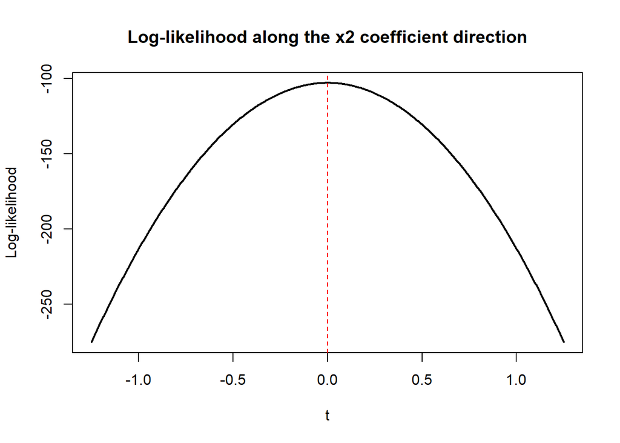

```r
e_x2 <- setNames(rep(0, ncol(X)), colnames(X))
e_x2["x2"] <- 1

t_grid <- seq(-1.25, 1.25, length.out = 501)

gaussian_log_likelihood <- function(beta, sigma2) {
  errors <- y - drop(X %*% beta)

  -n / 2 * log(2 * pi * sigma2) -
    sum(errors^2) / (2 * sigma2)
}

log_likelihood_values <- vapply(
  t_grid,
  function(t_value) {
    gaussian_log_likelihood(
      beta_hat + t_value * e_x2,
      sigma2_mle
    )
  },
  numeric(1)
)

maximizing_t <- t_grid[which.max(log_likelihood_values)]

plot(
  t_grid,
  log_likelihood_values,
  type = "l",
  lwd = 2,
  xlab = "t",
  ylab = "Log-likelihood",
  main = "Log-likelihood along the x2 coefficient direction"
)
abline(v = 0, lty = 2, col = "red")
```

**Show R code**

```r
data.frame(
  metric = "grid value of t with maximum log-likelihood",
  value = maximizing_t
)
```

```
                                       metric value
1 grid value of t with maximum log-likelihood     0
```

The curve reaches its maximum at $t=0$. At this point I have not changed the least-squares coefficient vector. Moving $t$ in either direction changes the $x_2$ coefficient and makes RSS larger, so the log-likelihood goes down. The plot therefore gives the same answer as the least-squares calculation.

## Question 3: Starting values in nonconvex optimization

### 3a. Plot and describe the objective function

**Show R code**

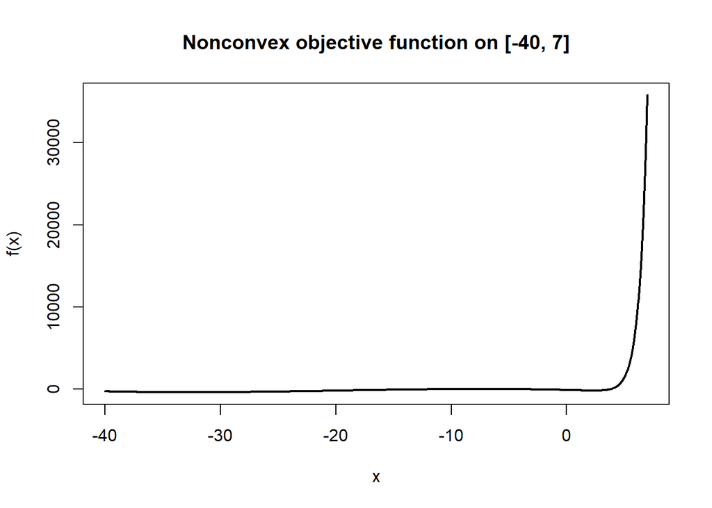

```r
objective_function <- function(x) {
  exp(1.5 * x) - 3 * (x + 6)^2 - 0.05 * x^3
}

objective_gradient <- function(x) {
  1.5 * exp(1.5 * x) - 6 * (x + 6) - 0.15 * x^2
}

x_grid <- seq(-40, 7, length.out = 2001)
objective_values <- objective_function(x_grid)

plot(
  x_grid,
  objective_values,
  type = "l",
  lwd = 2,
  xlab = "x",
  ylab = "f(x)",
  main = "Nonconvex objective function on [-40, 7]"
)
```

From the plot, I can see two different low regions rather than one bowl-shaped minimum. The curve changes direction and curvature between them, so the function is not convex. A local optimizer starting on one side may move into a different valley from an optimizer starting on the other side.

### 3b. Run BFGS from two starting values

**Show R code**

```r
run_bfgs <- function(starting_value) {
  fit <- optim(
    par = starting_value,
    fn = objective_function,
    gr = objective_gradient,
    method = "BFGS",
    control = list(
      maxit = 1000,
      reltol = 1e-12
    )
  )

  data.frame(
    starting_value = starting_value,
    final_x = unname(fit$par),
    final_objective = unname(fit$value),
    absolute_gradient = abs(objective_gradient(fit$par)),
    convergence_code = fit$convergence,
    optimizer_reported_convergence = fit$convergence == 0
  )
}

bfgs_results <- rbind(
  run_bfgs(-15),
  run_bfgs(0)
)

print(bfgs_results, digits = 8)
```

```
  starting_value     final_x final_objective absolute_gradient convergence_code
1            -15 -32.6491107      -390.38577     3.9442222e-07                0
2              0   2.3499673      -175.86262     6.7106226e-06                0
  optimizer_reported_convergence
1                           TRUE
2                           TRUE
```

Starting at $-15$, I get $x=-32.6491$, $f(x)=-390.3858$, and an absolute gradient of about $3.94\times10^{-7}$. Starting at 0 gives $x=2.3500$, $f(x)=-175.8626$, and an absolute gradient of about $6.71\times10^{-6}$. Both runs return convergence code 0. That tells me both runs settled near stationary points, but it does not say that both points are global minima.

### 3c. Interpret the different optimization results

BFGS uses information near its current location, so its starting value matters for a nonconvex function. Here the two starts lead to different valleys. Of the two answers, the point near $-32.6491$ is lower. I still would not call it the global minimum from only two runs. I would try more starting values and compare the values on a dense grid, or find all stationary points and compare them.

## Question 4: Nearly collinear predictors

### 4a. Compare the original and augmented design matrices

**Show R code**

```r
set.seed(43202)

# The same u is used in both x6 and y_star.
u <- rnorm(n)
x6 <- X[, "x1"] + 1e-4 * u
X_plus <- cbind(X, x6 = x6)
y_star <- y + 1e-3 * u

stable_least_squares <- function(design_matrix, response) {
  coefficients <- qr.solve(design_matrix, response)
  fitted <- drop(design_matrix %*% coefficients)
  residual <- response - fitted

  list(
    coefficients = coefficients,
    fitted = fitted,
    residuals = residual,
    rmse = sqrt(mean(residual^2))
  )
}

fit_X_y <- stable_least_squares(X, y)
fit_Xplus_y <- stable_least_squares(X_plus, y)

design_comparison <- data.frame(
  design = c("X", "X_plus"),
  condition_number = c(
    kappa(X, exact = TRUE),
    kappa(X_plus, exact = TRUE)
  ),
  training_rmse = c(
    fit_X_y$rmse,
    fit_Xplus_y$rmse
  ),
  x1_coefficient = c(
    unname(fit_X_y$coefficients["x1"]),
    unname(fit_Xplus_y$coefficients["x1"])
  ),
  x6_coefficient = c(
    NA_real_,
    unname(fit_Xplus_y$coefficients["x6"])
  )
)

print(design_comparison, digits = 7)
```

```
  design condition_number training_rmse x1_coefficient x6_coefficient
1      X         1.524914     0.6763696        1.41716             NA
2 X_plus     20209.203501     0.6754668      351.67661      -350.2588
```

The first result that stands out is the condition number: it changes from about 1.5249 for $X$ to 20,209.2 for $X_+$. The training RMSE barely changes, from 0.6764 to 0.6755. At the same time, the fitted coefficients are 351.6766 for $x_1$ and $-350.2588$ for $x_6$. The large condition number warns me that these individual coefficients can react strongly to small changes in the data.

### 4b. Perturb the response and compare coefficients and fitted values

**Show R code**

```r
fit_Xplus_ystar <- stable_least_squares(X_plus, y_star)

coefficient_changes <-
  fit_Xplus_ystar$coefficients - fit_Xplus_y$coefficients

fitted_value_changes <-
  fit_Xplus_ystar$fitted - fit_Xplus_y$fitted

coefficient_change_table <- data.frame(
  term = c("x1", "x6"),
  coefficient_for_y = c(
    unname(fit_Xplus_y$coefficients["x1"]),
    unname(fit_Xplus_y$coefficients["x6"])
  ),
  coefficient_for_y_star = c(
    unname(fit_Xplus_ystar$coefficients["x1"]),
    unname(fit_Xplus_ystar$coefficients["x6"])
  ),
  change = c(
    unname(coefficient_changes["x1"]),
    unname(coefficient_changes["x6"])
  )
)

fitted_value_comparison <- data.frame(
  metric = c(
    "root mean squared fitted-value difference",
    "maximum absolute fitted-value difference"
  ),
  value = c(
    sqrt(mean(fitted_value_changes^2)),
    max(abs(fitted_value_changes))
  )
)

print(coefficient_change_table, digits = 8)
```

```
  term coefficient_for_y coefficient_for_y_star change
1   x1         351.67661              341.67661    -10
2   x6        -350.25876             -340.25876     10
```

**Show R code**

```r
print(fitted_value_comparison, digits = 8)
```

```
                                     metric        value
1 root mean squared fitted-value difference 0.0010158794
2  maximum absolute fitted-value difference 0.0025726754
```

After changing $y$ to $y^\star$, the $x_1$ coefficient drops by 10 and the $x_6$ coefficient rises by 10. Their new values are 341.6766 and $-340.2588$. Even with these large coefficient shifts, the RMS fitted-value difference is only 0.001016 and the maximum difference is 0.002573. So the coefficients look unstable, while the fitted values are almost unchanged.

### 4c. Explain the instability

Here $x_6-x_1$ is very small. Increasing the $x_6$ coefficient by 10 while decreasing the $x_1$ coefficient by 10 changes the fitted values by exactly $10(x_6-x_1)=y^\star-y$. The two coefficient changes mostly cancel each other. For me, the main point is that the model can still predict well but cannot reliably decide how much of the effect belongs separately to $x_1$ and $x_6$.

## Question 5: Data preparation and summary statistics

### 5a. Inspect the raw data and construct the analysis table

**Show R code**

```r
raw_data <- read.csv(
  "data/data-manipulation.csv",
  stringsAsFactors = FALSE
)

raw_dimensions <- dim(raw_data)
column_types <- vapply(
  raw_data,
  function(column) paste(class(column), collapse = "/"),
  character(1)
)
duplicated_identifier_count <-
  sum(duplicated(raw_data$observation_id))
missing_value_counts <- colSums(is.na(raw_data))

data.frame(
  quantity = c("number of rows", "number of columns"),
  value = raw_dimensions
)
```

```
           quantity value
1    number of rows    24
2 number of columns     5
```

**Show R code**

```r
data.frame(
  column = names(column_types),
  type = unname(column_types),
  missing_values = unname(missing_value_counts),
  row.names = NULL
)
```

```
          column      type missing_values
1 observation_id character              0
2          group character              0
3             x1   numeric              0
4             x2   numeric              0
5       response   numeric              3
```

**Show R code**

```r
data.frame(
  metric = "duplicated observation_id values",
  value = duplicated_identifier_count
)
```

```
                            metric value
1 duplicated observation_id values     0
```

**Show R code**

```r
analysis_data <- raw_data[
  !is.na(raw_data$response),
  ,
  drop = FALSE
]

analysis_data$feature_sum <-
  analysis_data$x1 + analysis_data$x2
```

The file has 24 rows and 5 columns. `observation_id` and `group` are character variables, and the other three columns are numeric. I found no duplicated IDs. There are three missing values, all in `response`. I kept the 21 rows with an observed response and then calculated `feature_sum = x1 + x2`; I did not fill in the missing responses.

### 5b. Group summaries

**Show R code**

```r
group_counts <- aggregate(
  observation_id ~ group,
  data = analysis_data,
  FUN = length
)
names(group_counts)[2] <- "n"

group_means <- aggregate(
  cbind(response, feature_sum) ~ group,
  data = analysis_data,
  FUN = mean
)
names(group_means)[2:3] <-
  c("mean_response", "mean_feature_sum")

group_summary <- merge(
  group_counts,
  group_means,
  by = "group",
  sort = TRUE
)

print(group_summary, digits = 6)
```

```
  group n mean_response mean_feature_sum
1     A 7       5.60000          3.60000
2     B 7       7.60286          4.92857
3     C 7       7.99714          6.58571
```

There are 7 retained observations in each group. Group A has mean response 5.6000 and mean `feature_sum` 3.6000. The two means for group B are 7.6029 and 4.9286, and for group C they are 7.9971 and 6.5857. These numbers only describe rows where `response` was recorded.

### 5c. Sort the analysis table and verify the data-processing conditions

**Show R code**

```r
ordered_analysis_data <- analysis_data[
  order(analysis_data$response, decreasing = TRUE),
  ,
  drop = FALSE
]

top_three <- head(
  ordered_analysis_data[
    ,
    c("observation_id", "group", "response", "feature_sum")
  ],
  3
)

print(top_three, row.names = FALSE, digits = 6)
```

```
 observation_id group response feature_sum
         obs-22     C     9.24         6.6
         obs-16     B     9.00         5.2
         obs-14     B     8.66         5.0
```

**Show R code**

```r
data_checks <- c(
  retained_rows_match_nonmissing_responses =
    nrow(analysis_data) == sum(!is.na(raw_data$response)),
  analysis_responses_have_no_missing_values =
    !anyNA(analysis_data$response),
  analysis_identifiers_are_unique =
    anyDuplicated(analysis_data$observation_id) == 0
)

stopifnot(all(data_checks))

data.frame(
  check = names(data_checks),
  passed = unname(data_checks),
  row.names = NULL
)
```

```
                                      check passed
1  retained_rows_match_nonmissing_responses   TRUE
2 analysis_responses_have_no_missing_values   TRUE
3           analysis_identifiers_are_unique   TRUE
```

The three largest responses belong to `obs-22`, `obs-16`, and `obs-14`. Their responses are 9.24, 9.00, and 8.66, with `feature_sum` values 6.60, 5.20, and 5.00. My checks confirm that the number of retained rows matches the number of nonmissing responses, no retained response is missing, and every retained ID is unique. All of them return `TRUE`.

## Question 6: Can 39 million Fitbit records represent US adults?

No code is required for this question. Write each response in your own words.

### 6a. Independence and unequal participant weights

I would not treat the daily records as independent because the same person can appear on many days. Their health, work schedule, and exercise habits carry over across those days, and neighboring days may also be related. People can contribute different numbers of records because they joined at different times, stopped wearing the device, forgot to charge it, or had synchronization problems. A direct average of all days therefore gives more weight to people who recorded more days, which is different from giving every adult equal weight.

### 6b. BYOD versus WEAR and causal interpretation

I do not think the median difference proves a causal effect of already owning a Fitbit. BYOD and WEAR were not randomly assigned groups. For example, someone with higher income or more interest in exercise may be more likely to buy a Fitbit and also more likely to walk more. The income and demographic differences reported in the question make this kind of preexisting group difference quite plausible.

### 6c. Participant selection and recorded-day selection

There are two selection problems here. First, All of Us volunteers and people willing to use and share Fitbit data may differ from US adults in income, technology access, health, or interest in exercise. Second, an observed day requires the device to be worn and synchronized. Days with illness, travel, low activity, charging, or device trouble may be missing more often. Having 39 million records can make an estimate look precise, but it does not remove these selection problems. The all-record average also still weights people by their number of recorded days instead of equally.